# Проект. Этап № 2. Алгоритмы.

Неравновесная агрегация, фрактальные кластеры

Ощепков Дмитрий, Алади Принц, Хамдамова Айжана, Козлов Всеволод

Российский университет дружбы народов, Москва, Россия

11 апреля 2025

# Информация

## Докладчики

- Ощепков Дмитрий
- Хамдамова Айжана
- Козлов Всеволод
- Алади Принц
- НФИбд-01-22

## Цели и задачи

**Цель работы**

Определить алгоритм построения модели неравновесной агрегации и фрактальной кластеризации. Описать основные принципы алгоритма.

## DLA (Диффузионно-ограниченная агрегация)

Сеточная модель: Частицы случайно блуждают по сетке и прилипают к кластеру, если оказываются рядом с ним.

Бессеточная модель: Частицы движутся в пространстве без сетки, прилипая к кластеру при сближении на расстояние взаимодействия. Результат: кластеры имеют фрактальную структуру с размерностью D ~ 1.71 на плоскости и D ~ 2.50 в трёхмерном пространстве.

Фрактальная размерность D описывает, как масса кластера растёт с увеличением его размера.

## DLA (Диффузионно-ограниченная агрегация)

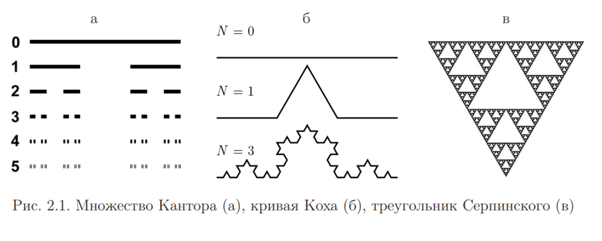

## DLA. Диффузия частицы

1. Изначально частицы свободно блуждают по пространству (Броуновское движение)
2. Пока не столкнутся с уже существующим кластером частиц (агрегатом)
3. После чего присоединяются к нему, и структура начинает расти.

$\Delta r(t) = \sqrt{2D\Delta t} \cdot \xi(t)$

*Δ**r*(*t*) — случайное смещение частицы за малый промежуток времени *Δ**t*,

*D* — коэффициент диффузии, определяющий скорость распространения частицы,

*Δ**t* — шаг по времени (мелкий интервал времени),

*ξ*(*t*) — случайная величина с нормальным распределением *N*(0, 1) (белый шум)

## DLA. Условие прилипания

Формула описывает условие прилипания частицы к кластеру.

min (∥**r**<sub>*i*</sub> − **r**<sub>cluster</sub>∥) ≤ *a*

**r**<sub>*i*</sub> — положение движущейся частицы,

**r**<sub>cluster</sub> — положение частиц в кластере,

*a* — радиус частицы,

$min (...)$ — минимальное расстояние между частицей и всеми точками кластера

## DLA. Фрактальная размерность

Масса растущего кластера увеличивается с радиусом по степенному закону с фрактальной размерностью D.

*M*(*R*) ∝ *R*<sup>*D*</sup>

*M*(*R*) — масса (или количество частиц) внутри круга (или сферы) радиуса *R*,

*R* — расстояние от центра (или радиус исследуемой области),

*D* — фрактальная размерность (характеризует, насколько “плотно” заполняется пространство кластером)

## DLA. Уравнение роста кластера

Формула описывает, как быстро растёт кластер DLA во времени.

$\frac{dR}{dt} \propto D \cdot n_0 \cdot R^{D - d}$

$\frac{dR}{dt}$ — скорость роста радиуса кластера со временем,

*D* — коэффициент диффузии (определяет, насколько быстро частицы распространяются),

*n*<sub>0</sub> — плотность частиц в окружающей среде (например, концентрация свободных диффундирующих частиц),

*R* — текущий радиус кластера,

*D* (в степени) — фрактальная размерность кластера,

## CLA (Химически-ограниченная агрегация)

В этой модели вероятность прилипания частицы к кластеру меньше 1. То есть частица может “отскочить” от кластера, даже если она находится рядом с ним.

Примеры антизотропных агрегатов для 3, 4, 5 и 6 осей симметрии:

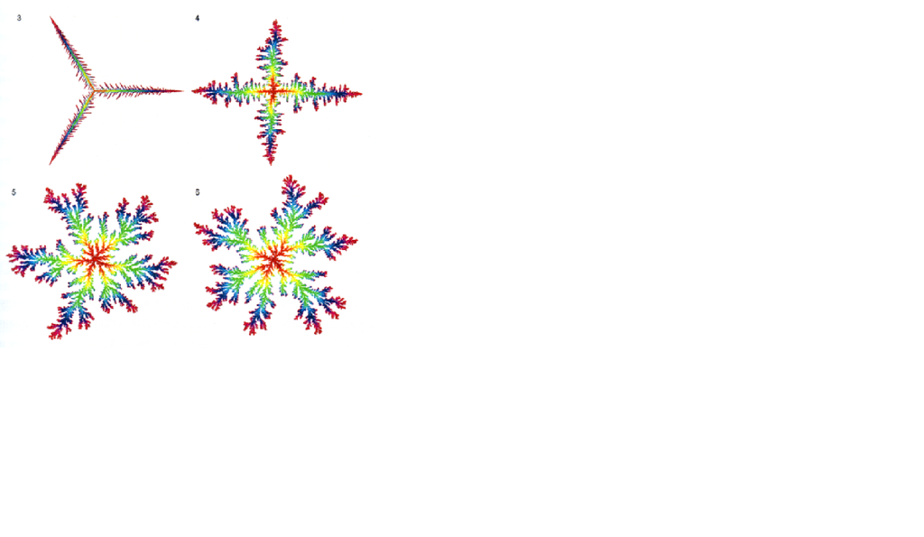

## CLA. Вероятность прилипания

Формула описывает, как температура и энергия активации влияют на вероятность прилипания частицы к кластеру. Если температура T высокая или энергия активации E низкая, вероятность прилипания будет выше. И наоборот.

$P_{\text{stick}} = p \cdot \exp\left(-\frac{E_b}{kT}\right)$

*P*<sub>stick</sub> — вероятность прилипания частицы к кластеру,

*p* — префактор (константа, которая учитывает общие вероятностные факторы),

*E*<sub>*b*</sub> — энергия активации для прилипания,

*k* — постоянная Больцмана,

*T* — температура системы.

## CLA. Динамика отскоков

Формула описывает движение частицы с учётом случайных колебаний.

$\mathbf{r}(t + \Delta t) = \mathbf{r}(t) + \sqrt{2D\Delta t} \cdot \xi(t)$

**r**(*t*) — положение частицы в момент времени *t*,

*D* — коэффициент диффузии (характеризует скорость распространения частицы),

*Δ**t* — шаг времени,

*ξ*(*t*) — случайная величина, которая моделирует случайное движение (обычно с нормальным распределением *N*(0, 1)).

## CLA. Фрактальная размерность

Формула описывает, как фрактальная размерность D(p) изменяется в зависимости от параметра p, который может быть связан с плотностью частиц или вероятностью прилипания в модели CCA

*D*(*p*) ≈ *d* − (*d* − *D*<sub>DLA</sub>) ⋅ *p*<sup>*α*</sup>

*D*(*p*) — фрактальная размерность кластера в зависимости от параметра *p*,

*d* — пространственная размерность (например, *d* = 2 для двумерного пространства, *d* = 3 — для трёхмерного),

*D*<sub>DLA</sub> — фрактальная размерность кластера в модели диффузионной ограниченной агрегации (DLA),

*p* — параметр, связанный с плотностью частиц или вероятностью прикрепления,

*α* — параметр, который определяет, как размерность меняется с параметром *p*

## BA (Баллистическая агрегация)

В этой модели частицы движутся по прямым траекториям (а не случайно блуждают, как в DLA). Они прилипают к кластеру при первом контакте.

## BA. Траектория частицы

Частица начинает движение с начальной позиции r0 с постоянной скоростью v и её положение в любой момент времени t можно вычислить по этой формуле. Таким образом, движение частицы линейное и прямолинейное с постоянной скоростью.

**r**(*t*) = **r**<sub>0</sub> + **v** ⋅ *t*

**r**(*t*) — положение частицы в момент времени *t*,

**r**<sub>0</sub> — начальное положение частицы (при *t* = 0),

$v$ — скорость частицы (вектор скорости),

*t* — время.

## BA. Условие прилипания

Когда движущаяся частица приближается к кластеру на расстояние не больше 2a (то есть когда их границы соприкасаются), она останавливается и становится частью кластера.

min (∥**r**(*t*) − **r**<sub>cluster</sub>∥) ≤ 2*a*

**r**(*t*) — положение движущейся частицы в момент времени *t*,

**r**<sub>cluster</sub> — положение всех частиц, входящих в кластер,

*a* — радиус частицы,

$∥⋅∥$ — евклидово расстояние между двумя точками в пространстве,

$min (...)$ — минимальное расстояние от текущей частицы до всех частиц кластера.

## BA. Фрактальная размерность

В модели баллистической агрегации (BA) частицы движутся по прямой и прилипают при столкновении, что приводит к более плотной структуре. Поэтому фрактальная размерность *D*<sub>BA</sub> выше, чем у кластера в модели DLA.

*D*<sub>BA</sub> ≈ 1.9–2.2 (для BA), *D*<sub>DLA</sub> ≈ 1.7 (для DLA)

*D*<sub>BA</sub> — фрактальная размерность кластера при баллистической агрегации,

*D*<sub>DLA</sub> — фрактальная размерность кластера при диффузионной ограниченной агрегации (DLA).

## CCA (Кластер-кластерная агрегация)

В этой модели несколько кластеров растут одновременно и могут слипаться друг с другом. Это отличается от DLA, где растёт только один кластер, а частицы прилипают к нему по одной.

## CCA. Динамика кластеров

Формула описывает радиус инерции кластера — важную характеристику, которая показывает, насколько “растянут” кластер в пространстве относительно его центра масс.

$R_{g,i} = \sqrt{\frac{1}{N} \sum_{j=1}^{N} \left( \mathbf{r}_j - \mathbf{r}_{\text{cm}} \right)^2}$

*R*<sub>*g*, *i*</sub>) — радиус инерции ( i )-го кластера (gyration radius),

*N* — число частиц (или мономеров) в кластере,

**r**<sub>*j*</sub> — позиционный вектор ( j )-й частицы в кластере,

**r**<sub>cm</sub> — вектор центра масс кластера.

## CCA. Правило слипания

Чем больше размеры кластеров (сумма радиусов инерции), тем выше вероятность их слипания

*P*<sub>*i**j*</sub> ∝ (*R*<sub>*g*, *i*</sub> + *R*<sub>*g*, *j*</sub>)<sup>*γ*</sup>

*P*<sub>*i**j*</sub> — вероятность слипания двух кластеров,

*γ* — параметр, задающий, насколько сильно вероятность слипания зависит от размеров кластеров

## CCA. Фрактальная размерность

Фрактальная размерность D характеризует, насколько плотно заполняется пространство частицами в кластере. В модели CCA агрегаты, как правило, менее плотные, чем в DLA, поскольку они формируются из слияния целых кластеров, а не по одной частице.

*D* — фрактальная размерность кластера в модели CCA (Cluster-Cluster Aggregation),

*D*<sub>DLA</sub> ≈ 1.71–1.75 — фрактальная размерность для модели DLA (Diffusion-Limited Aggregation).

## Выводы

Во время выполнения второго этапа группового проекта мы определили алгоритм построения модели неравновесной агрегации и фрактальной кластеризации. Описали основные принципы алгоритма.

## Список литературы

1. Медведев Д.А. и др. Моделирование физических процессов и явлений на ПК: Учеб. пособие. Новосибирск: Новосиб. гос. ун-т, 2010. 101 с.
2. Sander L.M. Diffusion-limited aggregation: A kinetic critical phenomenon? Contemporary Physics, 2000.
3. Тыртышников А.Ю. и др. Сравнение алгоритмов DLA и RLA при моделировании пористых структур. НИИ «Центрпрограммсистем», 2017. 244 с.